# BDA_report

**考虑变量间可能存在的交互影响，重新生成模型**

```
Call:
glm(formula = happiness ~ religion + marital + health + age +
    income + equity + inc_ability + age * health + age * income +
    health * income, family = poisson(), data = glm_data)

Deviance Residuals:
     Min        1Q    Median        3Q       Max
-1.94762  -0.16150   0.02621   0.20971   1.47565

Coefficients:
                            Estimate Std. Error z value Pr(>|z|)
(Intercept)                8.617e-01  2.144e-01   4.019 5.85e-05 ***
religion1 有宗教          -3.477e-02  2.046e-02  -1.699 0.089258 .
marital2 同居              5.226e-02  7.832e-02   0.667 0.504651
marital3 初婚有配偶        4.309e-02  2.494e-02   1.728 0.084052 .
marital4 再婚有配偶        9.327e-03  5.307e-02   0.176 0.860500
marital5 分居未离婚       -2.923e-02  1.130e-01  -0.259 0.795930
marital6 离婚             -6.913e-02  5.053e-02  -1.368 0.171336
marital7 丧偶              1.317e-02  3.563e-02   0.370 0.711636
health2 比较不健康         3.724e-01  2.168e-01   1.717 0.085945 .
health3 一般               4.127e-01  2.093e-01   1.972 0.048574 *
health4 比较健康           4.852e-01  2.042e-01   2.376 0.017484 *
health5 很健康             5.792e-01  2.068e-01   2.800 0.005107 **
age                        3.628e-03  2.957e-03   1.227 0.219929
income                     6.984e-03  1.313e-02   0.532 0.594784
equity2 比较不公平         1.480e-02  3.178e-02   0.466 0.641478
equity3 说不上公平不公平   5.982e-02  3.177e-02   1.883 0.059727 .
equity4 比较公平           1.174e-01  3.041e-02   3.860 0.000114 ***
equity5 完全公平           2.083e-01  4.350e-02   4.789 1.67e-06 ***
inc_ability2 合理         -6.666e-02  4.628e-02  -1.440 0.149795
inc_ability3 非常合理     -1.107e-01  4.740e-02  -2.336 0.019501 *
inc_ability4 非常不合理   -1.809e-01  6.036e-02  -2.998 0.002721 **
health2 比较不健康:age    -3.281e-03  3.067e-03  -1.070 0.284696
health3 一般:age          -3.093e-03  2.939e-03  -1.053 0.292503
health4 比较健康:age      -3.649e-03  2.867e-03  -1.273 0.203097
health5 很健康:age        -3.991e-03  2.935e-03  -1.360 0.173858
age:income                 7.684e-05  1.167e-04   0.658 0.510372
health2 比较不健康:income -8.225e-03  1.182e-02  -0.696 0.486387
health3 一般:income       -7.896e-03  1.181e-02  -0.669 0.503645
health4 比较健康:income   -8.536e-03  1.140e-02  -0.749 0.454088
health5 很健康:income     -1.121e-02  1.188e-02  -0.943 0.345541
---
Signif. codes:  0 ‘***’ 0.001 ‘**’ 0.01 ‘*’ 0.05 ‘.’ 0.1 ‘ ’ 1

(Dispersion parameter for poisson family taken to be 1)

    Null deviance: 1260.9  on 6622  degrees of freedom
Residual deviance: 1049.9  on 6593  degrees of freedom
AIC: 22362

Number of Fisher Scoring iterations: 4
```

- 由上述结果可以看出，健康状况、社会公平、收入合理性对幸福感依然有显著影响，交互作用对模型的影响不显著

**模型可视化**

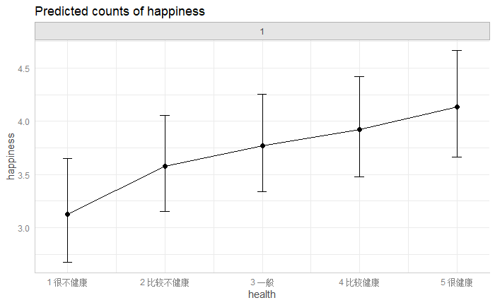

```r
#用图形直观查看健康对幸福感的影响
dat1 <-ggpredict(model2,terms=list("health"))
plot(dat1,facet=TRUE)+geom_line()
```

- 由图可看出，健康对幸福感有显著正面影响

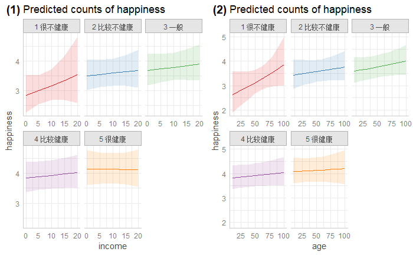

```r
#将两张图并列放置
library(ggpubr)
ggarrange(P1,P2,ncol=2,labels=c("(1)","(2)"))
```

- 由图可以看出，在控制了其他变量的基础上，收入、年龄对幸福感的影响总体来说并不十分显著（只有当健康状况为很不健康时，幸福感变化较大）

**逐步回归**

```r
model3 <- step(model2)
```

```
Start:  AIC=22361.96
happiness ~ religion + marital + health + age + income + equity +
    inc_ability + age * health + age * income + health * income

                Df Deviance   AIC
- health:income  4   1050.9 22355
- health:age     4   1052.0 22356
- age:income     1   1050.3 22360
- marital        6   1061.1 22361
<none>               1049.9 22362
- religion       1   1052.8 22363
- inc_ability    3   1068.5 22375
- equity         4   1111.0 22415

Step:  AIC=22354.95
happiness ~ religion + marital + health + age + income + equity +
    inc_ability + health:age + age:income

              Df Deviance   AIC
- health:age   4   1053.0 22349
- marital      6   1061.9 22354
- age:income   1   1052.1 22354
<none>             1050.9 22355
- religion     1   1053.8 22356
- inc_ability  3   1069.6 22368
- equity       4   1112.1 22408

Step:  AIC=22349.03
happiness ~ religion + marital + health + age + income + equity +
    inc_ability + age:income

              Df Deviance   AIC
- marital      6   1063.7 22348
- age:income   1   1054.1 22348
<none>             1053.0 22349
- religion     1   1055.7 22350
- inc_ability  3   1071.9 22362
- equity       4   1114.6 22403
- health       4   1117.3 22405

```

[output cut: 19 more lines]

```
- age          1   1069.2 22349
- inc_ability  3   1084.3 22360
- equity       4   1126.3 22400
- health       4   1130.7 22405

Step:  AIC=22345.84
happiness ~ religion + health + age + equity + inc_ability

              Df Deviance   AIC
<none>             1065.8 22346
- religion     1   1068.0 22346
- age          1   1070.2 22348
- inc_ability  3   1085.8 22360
- equity       4   1127.2 22399
- health       4   1134.4 22406
```

```r
summary(model3)
```

```
Call:
glm(formula = happiness ~ religion + health + age + equity +
    inc_ability, family = poisson(), data = glm_data)

Deviance Residuals:
     Min        1Q    Median        3Q       Max
-1.92911  -0.14940   0.03002   0.20730   1.33521

Coefficients:
                           Estimate Std. Error z value Pr(>|z|)
(Intercept)               1.1473466  0.0731297  15.689  < 2e-16 ***
religion1 有宗教         -0.0307667  0.0203890  -1.509  0.13130
health2 比较不健康        0.1141481  0.0439744   2.596  0.00944 **
health3 一般              0.1708858  0.0428259   3.990 6.60e-05 ***
health4 比较健康          0.2076741  0.0421698   4.925 8.45e-07 ***
health5 很健康            0.2640749  0.0433915   6.086 1.16e-09 ***
age                       0.0008853  0.0004208   2.104  0.03540 *
equity2 比较不公平        0.0171432  0.0317366   0.540  0.58908
equity3 说不上公平不公平  0.0619881  0.0317087   1.955  0.05059 .
equity4 比较公平          0.1203323  0.0303511   3.965 7.35e-05 ***
equity5 完全公平          0.2066683  0.0434474   4.757 1.97e-06 ***
inc_ability2 合理        -0.0716521  0.0461973  -1.551  0.12090
inc_ability3 非常合理    -0.1162733  0.0472984  -2.458  0.01396 *
inc_ability4 非常不合理  -0.1913375  0.0601733  -3.180  0.00147 **
---
Signif. codes:  0 ‘***’ 0.001 ‘**’ 0.01 ‘*’ 0.05 ‘.’ 0.1 ‘ ’ 1

(Dispersion parameter for poisson family taken to be 1)

    Null deviance: 1260.9  on 6622  degrees of freedom
Residual deviance: 1065.8  on 6609  degrees of freedom
AIC: 22346

Number of Fisher Scoring iterations: 4
```

- 逐步回归由系统自动挑选最佳的回归方程，我们可以看到系统自动去掉了不显著的交互项，级该交互效应在我们所研究的问题上没有统计学上的意义。最终得到的公式为 formula = happiness ~ religion + health + age + equity + inc_ability